# The Rise of Humans

## What does it mean to be human?

**The meaning of the term “humanism” has changed across successive intellectual movements that have identified with it. Generally, the term refers to a focus on human well-being and advocates for human freedom, autonomy, and progress. It views humanity as responsible for the promotion and development of individuals, espouses the equal and inherent dignity of all human beings, and emphasizes a concern for humans in relation to the world.**

**We were not alone - ’Humans” have a rich and interesting evolutionary history**

**‘Humans’ have interacted with the biosphere from our origins till today**

**What does it mean, in your opinion, to be ‘Human’**

**Does your perspective on the Anthropocene influence your views on ‘humanism’?**

**What are a few reasons this cartoon depicting human evolution lacks accuracy and is problematic?**

[figure not shown]

## Misconceptions about human evolution

**Humans did not evolve from chimps, we both descended from a common ancestor**

**Early human evolution was not a linear progression but a branching tree**

**Multiple species of ancient humans walked the earth at the same time**

**Modern humans originated in Africa and then spread around the world evolving incredible diversity (so the buff-white-male-endpoint is not only ridiculous but problematic in many ways)**

**There is no endpoint, humans are still evolving**

## Think Critically: Global Question…

**What are the consequences of misconceptions about human evolution past, present & future?**

**Is egocentrism at the root of environmental issues?**

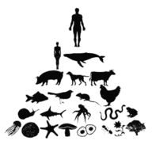

## Human evolution fact and fallacies

- **Humans are a part of the tree of life, not above it**
  - Aristotle and Scala Natura is wrong
- **Humans are the only species capable of free thinking…**
  - dolphins and bonobos have sex for fun
- **Are humans the most complex organism on Earth?**
  - octopus eye vs human eye
- **Nothing that exists on Earth is actually ‘primitive’**
  - consider the basics of evolution and selection!
- **Why does this matter now, especially in Appalachia?**
  - societies/cultures create false hierarchies based on ladder approach

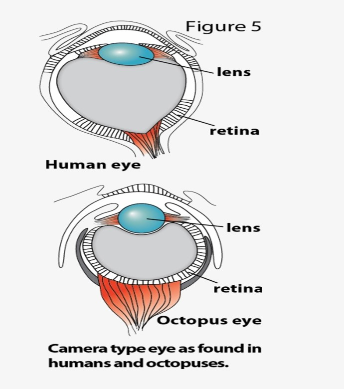

## Dangers of false hierarchies

**Manufactured tiers within human species based on the ladder approach to evolution**

**A more perfect race of humans is developing/evolving (or can be created)**

**Used to uphold white supremacy, imperialism, colonialism, slavery and genocide**

**Used to create eugenics programs**

**Generate negative, oversimplified and misleading characterizations of Appalachian people: uneducated, resistant to change, isolated, reliant of assistance, etc…**

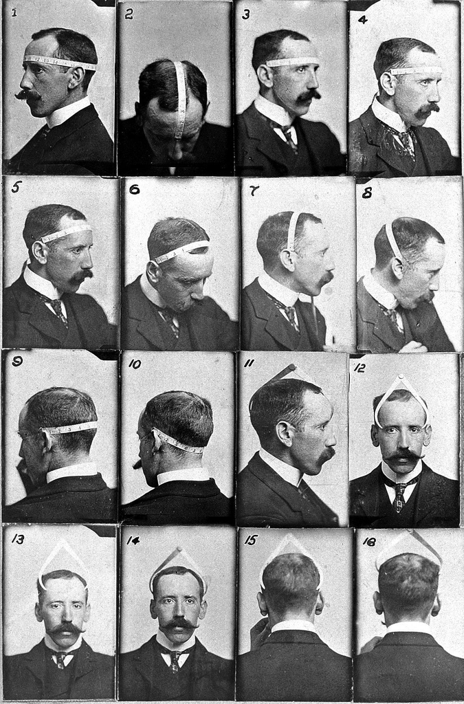

## Misconception: Trees not ladders!

- **Aristole (Scala Natura & Great Chain of Being) was wrong**
- **Phylogenies do not imply that organisms are more advanced**
  - pathways of evolutionary novelties that makes each taxa unique
  - unique does not have to mean more complex
    - reductive evolution: loss of genes for eyesight, pigmentation in trout living in Appalachian caves

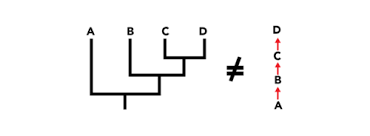

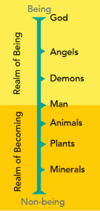

## Humans ARE the new kids on the block

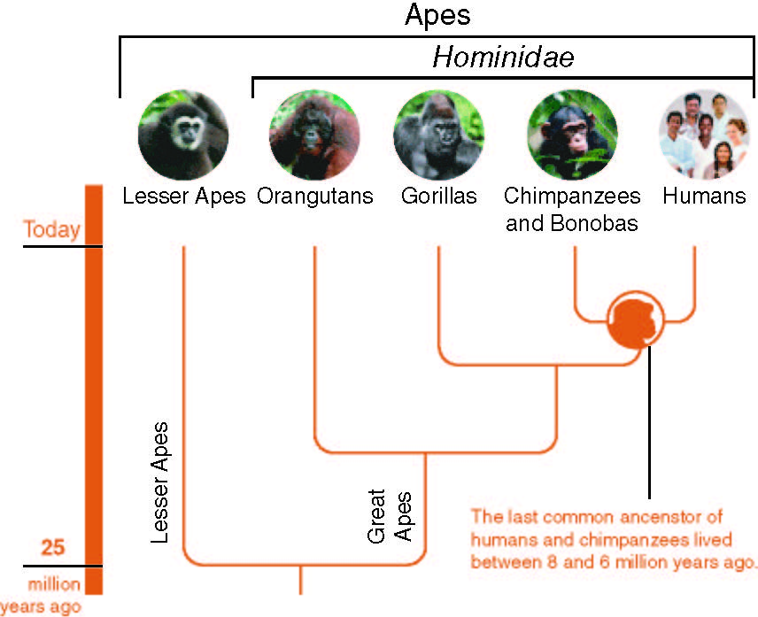

- **Humans belong to a family of primates**
  - group also contains chimps, gorillas and orangutans
- **Our genus (*Homo*) shares a common ancestor with chimps (*Pan*)**
  - early ‘humans’ and *Pan* diverged 6-8mya
  - the split did not create *our* species
- **Homo sapien’s evolutionary history is BRIEF**

## Whats in a name - Relatedness through taxonomy

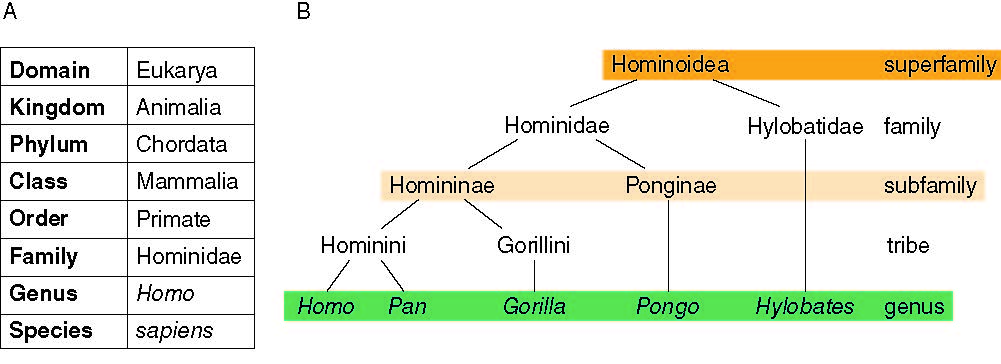

## Hominin tribe includes several genera, including *Homo*

- **Ancestral ‘humans’ can be split into ~4 groups (genera)**
- **Groupings relate to timing and evolutionary milestones**
  - gets messy the farther you go back (lack of fossils)
- **Fossil record is very incomplete**
  - common ancestor with *Pan* is unknown
  - total number of ancestral humans may change
  - *Toumai* fossil (Chad) dated 6-7 mya
  - *Ardi* fossil (Ethiopia) dated 4.4 mya
  - First *Homo* fossil dated 2.8 mya
  - First *Homo sapiens* fossil dated 300,000 ya
  - Oldest Appalachian *Homo sapiens* presence -> 14,000 ya

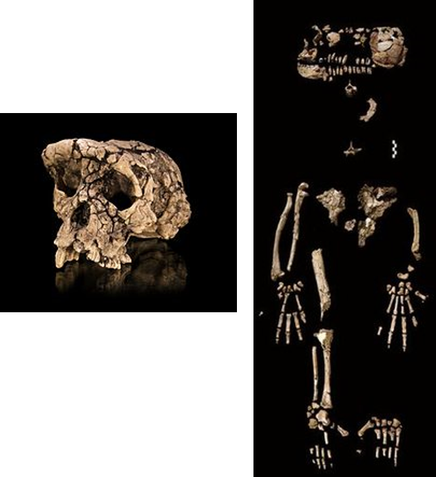

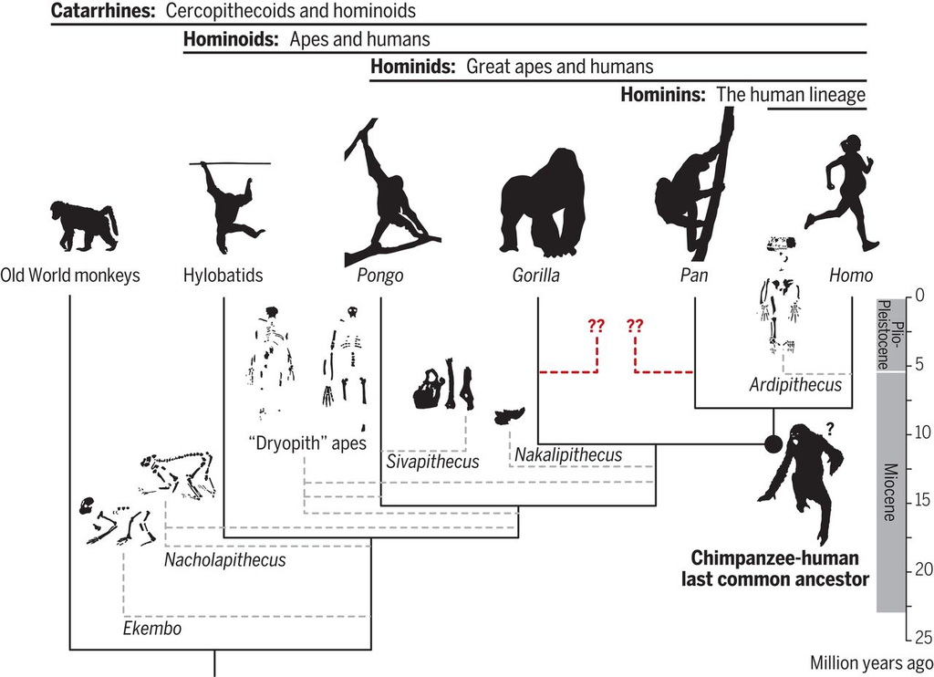

## *Homo sapiens* are the last ‘humans’ standing

- **Homo habilis was probably first (most primitive) member of our genus (>2 mya)**
- **Homo sapiens evolved approx. 300,00 - 200,00 years ago**
- **The evolution of the *Homo* genus was not a ladder!**

[figure not shown]

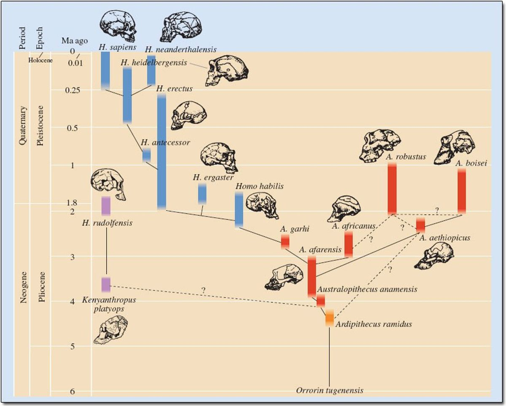

## Different species of *Homo* very likely interacted

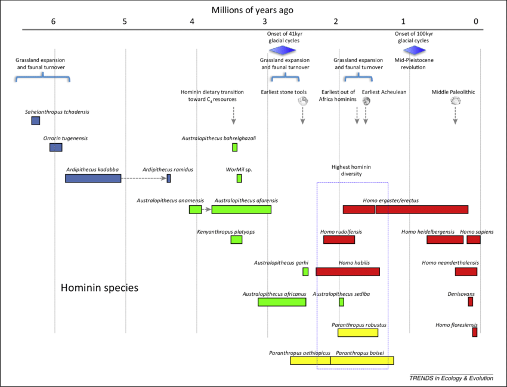

## Out of Africa and beyond for humans

- **H. sapiens evolved on African continent**
  - massive migration ~100,000 ya
  - not the first to leave
- **H. erectus probably left first**
  - or H. egaster
- **H. neanderthalensis evolved in Europe/Asia**
- **Our species left in a 2<sup>nd</sup> migration**
- **Lots of debate!!**

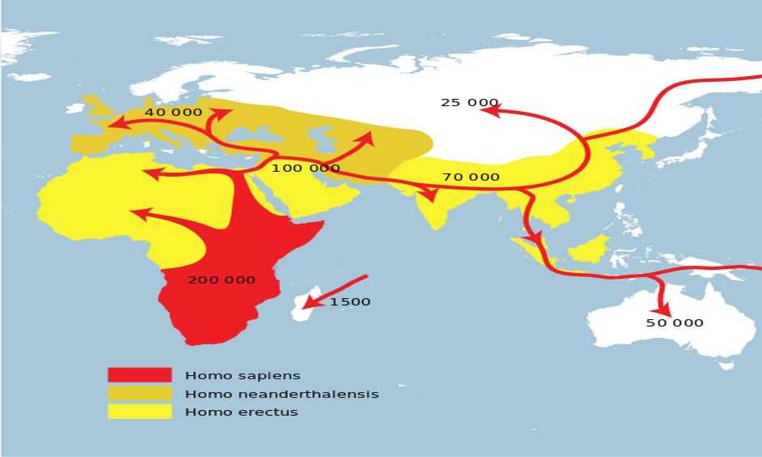

## Different species of *Homo* likely interbred

- **Humans from outside Africa have traces of Neanderthal DNA**
  - about 1–2% of their genomes
  - fossils overlap in Middle East (~50,000 ya)
- **DNA from a 40,000-year-old human skeleton suggests a Neanderthal great-great grandparent**
- **Modern *Homo sapien* genomes carry Neanderthal genes that affect blood clotting, allergies and possible depression!**

[figure not shown]

- **H. sapiens just about everywhere by 15,000ya**
  - beyond other *Homo* spp.
  - Out competed other *Homo* spp.
- **Adapted to become ecological generalist/specialist**
  - able to persist anywhere (generalist)
  - able to persist in extreme places (specialist)

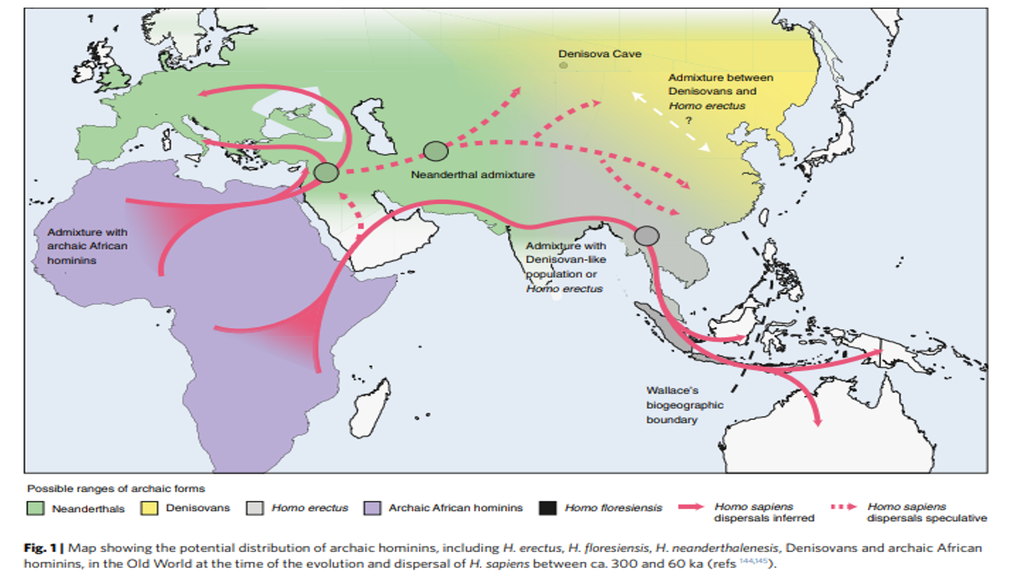

## Early Homo sapien migration altered the landscape

- **Humans have always been hunters**
- **Human arrival associated with biodiversity loss**
  - centered around larger animals
  - impacted whole ecosystems
- **Islands are great case studies**
  - Humans caused extinction of Moa and giant Eagle on New Zealand but introduced non-natives mammals
- **Humans not the only reason big animals disappear…**
  - related to big climate shifts

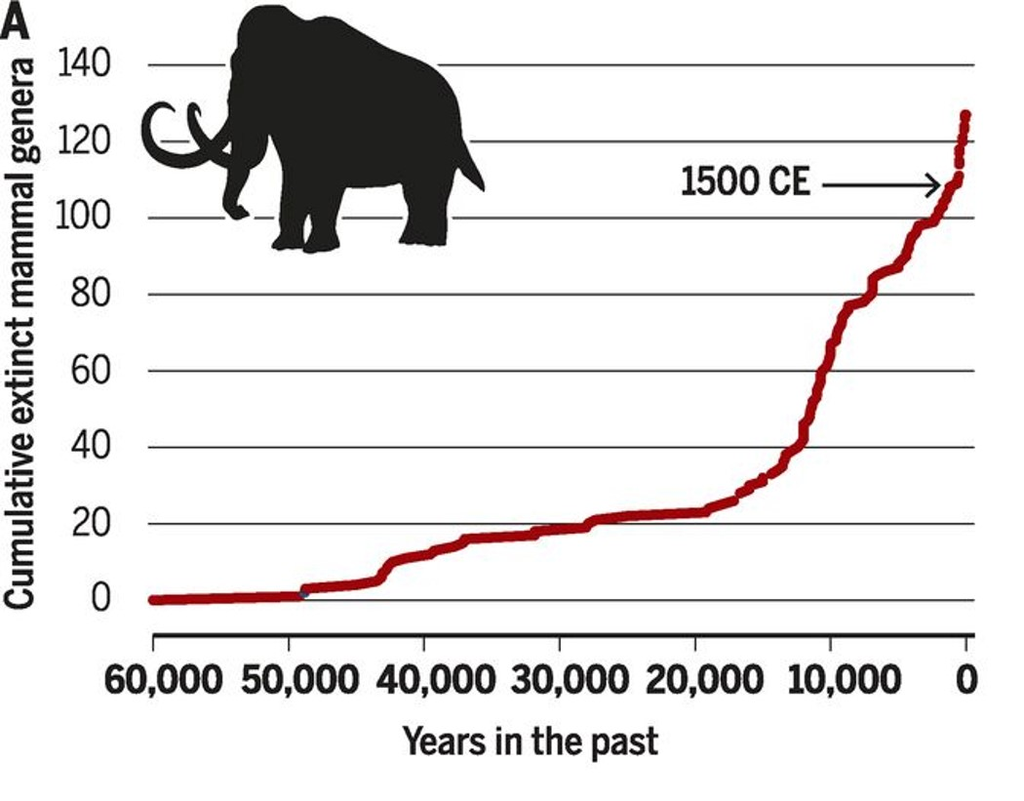

## H.sapien population increased slowly until farming (11,000ya)

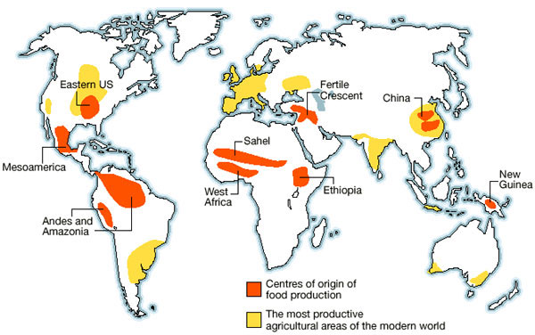

## Why does this matter for global change?

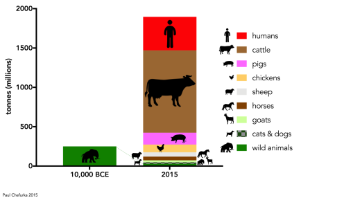